# Домашняя работа №7, Плеханов Антон, 316

**Задания из комментариев**

Перерисованный barplot для количества успешных/неуспешных исходов в экспериментальной и контрольной группах для каждого медицинского центра:

```r
drug <-
  array(c(11, 10, 25, 27,
          16, 22, 4, 10,
          14, 7, 5, 12,
          2, 1, 14, 16,
          6, 0, 11, 12,
          1, 0, 10, 10,
          1, 1, 4, 8,
          4, 6, 2, 1),
        dim = c(2, 2, 8),
        dimnames = list(
          Group = c("Препарат", "Контроль"),
          Response = c("Успешно", "Неудачно"),
          Center = c("1", "2", "3", "4", "5", "6", "7", "8")))

library(reshape) # для функции melt()
drug.df <- data.frame(melt(drug,
                            id=c("Group", "Center", "Response")))
drug.df
```

| Group | Response | Center | value |
| --- | --- | --- | --- |
| Препарат | Успешно | 1 | 11 |
| Контроль | Успешно | 1 | 10 |
| Препарат | Неудачно | 1 | 25 |
| Контроль | Неудачно | 1 | 27 |
| Препарат | Успешно | 2 | 16 |
| Контроль | Успешно | 2 | 22 |
| Препарат | Неудачно | 2 | 4 |
| Контроль | Неудачно | 2 | 10 |
| Препарат | Успешно | 3 | 14 |
| Контроль | Успешно | 3 | 7 |

[output cut: 22 more lines]

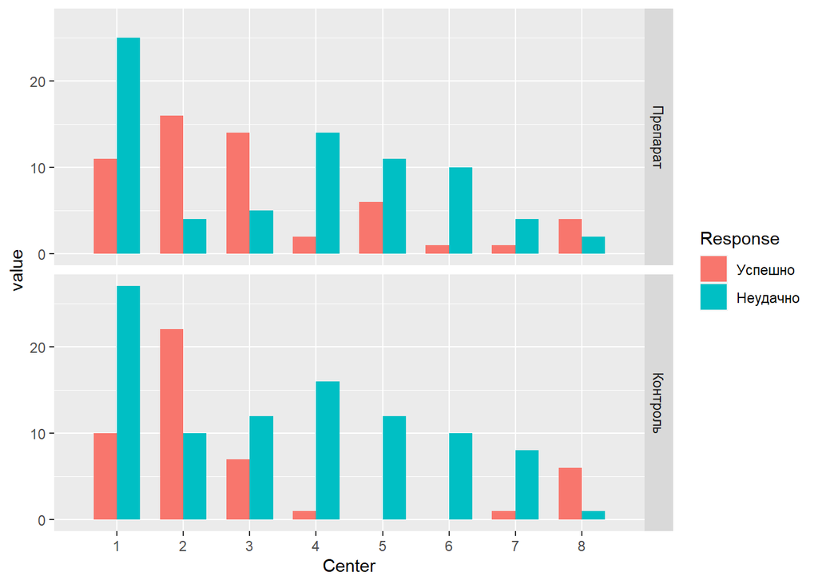

```r
library(ggplot2)
p1 <- ggplot(data = drug.df, aes(x = Center, y = value, fill = Response, width = 0.7))
p1 + geom_bar(stat = 'identity', position = 'dodge') +
  facet_grid(Group~.) +
  scale_x_discrete(limits=c(1:8))
```

**Корреляционные взаимосвязи для датасета**

Загрузка данных.

```r
file <- file.choose()
```

```r
data <- read.csv(file)
attach(data)
```

Структура данных:

```r
str(data)
```

```
## 'data.frame':    12181 obs. of  22 variables:
##  $ price                : int  8000000 7200000 10300000 8500000 9000000 8050000 10900000 8100000 10000000 9000000 ...
##  $ repair               : int  3 2 2 2 2 2 2 2 3 3 ...
##  $ year_built_empty     : int  0 0 0 0 0 0 0 0 0 0 ...
##  $ house_age            : int  42 43 43 43 43 38 35 32 45 44 ...
##  $ closest_subway       : int  59 59 59 59 59 59 59 59 59 59 ...
##  $ dist_to_subway       : int  960 802 638 929 785 962 556 859 1323 796 ...
##  $ sg                   : num  0 0 0 0 0 0 0 0 0 0 ...
##  $ lat                  : num  55.6 55.6 55.6 55.6 55.6 ...
##  $ lon                  : num  37.7 37.7 37.7 37.7 37.7 ...
##  $ subway_dist_to_center: int  17166 17166 17166 17166 17166 17166 17166 17166 17166 17166 ...
##  $ h3                   : chr  "861181b6fffffff" "861181b4fffffff" "861181b4fffffff" "861181b6fffffff" ...
##  $ agent_offers         : int  1 1 57 292 292 292 57 36 65 1 ...
##  $ subway_offers        : int  5 9 9 5 5 5 9 13 6 9 ...
##  $ address_offers       : num  1 1 2 1 1 1 1 1 1 1 ...
##  $ rooms                : int  1 1 2 2 2 1 2 1 2 2 ...
##  $ footage              : num  39.4 35.6 53 44.1 44.2 39.5 57 33.9 45.9 45.8 ...
##  $ floor                : int  11 2 5 8 6 1 19 2 10 6 ...
##  $ max_floor            : int  12 9 12 9 9 12 22 22 12 12 ...
##  $ first_floor          : int  0 0 0 0 0 1 0 0 0 0 ...
##  $ last_floor           : int  0 0 0 0 0 0 0 0 0 0 ...
##  $ AO                   : chr  "UAO" "UAO" "UAO" "UAO" ...
##  $ hm                   : chr  "panel" "panel" "panel" "panel" ...
```

*Коэффициенты корреляции между ценой и качеством ремонта*

Коэффициент корреляции Пирсона показывает линейную зависимость между выборками, в случае, если они распределены нормально.

Поскольку качество ремонта - целое число от 1 до 4, о нормальной распределенности этого признака речи не идет. Использование же корреляции Спирмана предполагает, что в выборках нет равных значений. Поэтому будем использовать коэффициент корреляции Кендалла:

```r
cor.test(price, repair, method='kendall')
```

```
##
##  Kendall's rank correlation tau
##
## data:  price and repair
## z = 19.327, p-value < 2.2e-16
## alternative hypothesis: true tau is not equal to 0
## sample estimates:
##       tau
## 0.1348473
```

P-value < 0.05, значит, гипотеза о равенстве нулю корреляции Кендалла отвергается. В то же время, значение корреляции, посчитанное по выборке, положительно и невелико, что говорит о прямой, но слабой взаимосвязи признаков.

*Коэффициенты корреляции между ценой и расстоянием до центра*

По вышеописанным причинам в для данной пары признаков корректно применять тест с корреляцией Кендалла

```r
cor.test(price, subway_dist_to_center, method = 'kendall')
```

```
##
##  Kendall's rank correlation tau
##
## data:  price and subway_dist_to_center
## z = -39.585, p-value < 2.2e-16
## alternative hypothesis: true tau is not equal to 0
## sample estimates:
##        tau
## -0.2411338
```

P-value < 0.05, значит, нулевая гипотеза о равенстве нулю коэффициента корреляции отвергается. Значение коэффициента корреляции < 0, следовательно присутствует обратная взаимосвязь между признаками (что логично, т.к. чем меньше расстояние до центра Москвы, тем дороже стоимость квартиры)

*Демонстрация применения корреляции Пирсона и Спирмана на модельных данных*

Покажем применение корреляций Пирсона и Спирмана на выборках из нормального распределения:

```r
set.seed(1234)
X1 <- rnorm(100, mean = 2, sd = 3)
X2 <- rnorm(100, mean = 0, sd = 1)

cor.test(X1, X2, method = 'pearson')
```

```
##
##  Pearson's product-moment correlation
##
## data:  X1 and X2
## t = -0.25136, df = 98, p-value = 0.8021
## alternative hypothesis: true correlation is not equal to 0
## 95 percent confidence interval:
##  -0.2207006  0.1718923
## sample estimates:
##         cor
## -0.02538285
```

```r
cor.test(X1, X2, method = 'spearman')
```

```
##
##  Spearman's rank correlation rho
##
## data:  X1 and X2
## S = 165406, p-value = 0.9412
## alternative hypothesis: true rho is not equal to 0
## sample estimates:
##         rho
## 0.007464746
```

```r
cor.test(X1, X2, method = 'kendall')
```

```
##
##  Kendall's rank correlation tau
##
## data:  X1 and X2
## z = 0.059562, p-value = 0.9525
## alternative hypothesis: true tau is not equal to 0
## sample estimates:
##         tau
## 0.004040404
```

Выборки Х1, Х2 были сгенерированы независимымо, поэтому значения всех коэффициентов корреляций близки к нулю.

Сгенерируем зависимые выборки из нормального распределения:

```r
X1 <- rnorm(100, mean = 2, sd = 2)
X2 <- (-2) * X1 + rnorm(100, mean = 0, sd = 0.5)

cor.test(X1, X2, method = 'pearson')
```

```
##
##  Pearson's product-moment correlation
##
## data:  X1 and X2
## t = -72.019, df = 98, p-value < 2.2e-16
## alternative hypothesis: true correlation is not equal to 0
## 95 percent confidence interval:
##  -0.9937336 -0.9861621
## sample estimates:
##        cor
## -0.9906845
```

```r
cor.test(X1, X2, method = 'spearman')
```

```
##
##  Spearman's rank correlation rho
##
## data:  X1 and X2
## S = 329996, p-value < 2.2e-16
## alternative hypothesis: true rho is not equal to 0
## sample estimates:
##       rho
## -0.980174
```

```r
cor.test(X1, X2, method = 'kendall')
```

```
##
##  Kendall's rank correlation tau
##
## data:  X1 and X2
## z = -13.247, p-value < 2.2e-16
## alternative hypothesis: true tau is not equal to 0
## sample estimates:
##        tau
## -0.8985859
```

В этом случае выборки значения всех коэффициентов корреляции близки к -1, т.е. показывают сильную обратную зависимость между выборками. Коэффициент корреляции Пирсона равен -0.99, что свидетельствует о сильной линейной зависимости признаков.

**Использование методов хи-квадрат, точного теста Фишера, Кохрана-Мантеля-Хензеля**

*Тест Хи-квадрат* Проверим с помощью теста Хи-квадрат, есть ли различие между расстоянием до ближайшего метро в юго-восточном (UVAO) и западном (ZAO) административных округах. Для этого создадим новый признак ‘sub_dist < threshold’, и зададим порог threshold = 1000м.

```r
threshold <- 1000
data[, "sub_dist < threshold"] <- as.numeric(data$dist_to_subway < threshold)
subdata <-
  data[data$AO == 'UVAO' | data$AO == 'ZAO', c('AO', 'sub_dist < threshold')]

cont.table <- table(subdata)
cont.table
```

```
##       sub_dist < threshold
## AO        0    1
##   UVAO  718 1335
##   ZAO   589 1005
```

```r
chisq.test(cont.table)
```

```
##
##  Pearson's Chi-squared test with Yates' continuity correction
##
## data:  cont.table
## X-squared = 1.4417, df = 1, p-value = 0.2299
```

P-value > 0.05, следовательно, отличие в частотах квартир с расстоянием до метро больше/меньше 1 км в западном и юго-восточном административных округах статистически незначимо.

*Точный тест Фишера*

Точный тест Фишера для той же таблицы сопряженности:

```r
fisher.test(cont.table)
```

```
##
##  Fisher's Exact Test for Count Data
##
## data:  cont.table
## p-value = 0.2232
## alternative hypothesis: true odds ratio is not equal to 1
## 95 percent confidence interval:
##  0.7989272 1.0542612
## sample estimates:
## odds ratio
##  0.9177081
```

P-value > 0.05. Точный тест Фишера так же принимает нулевую гипотезу.

*Критерий Кохрана-Мантеля-Хензеля*

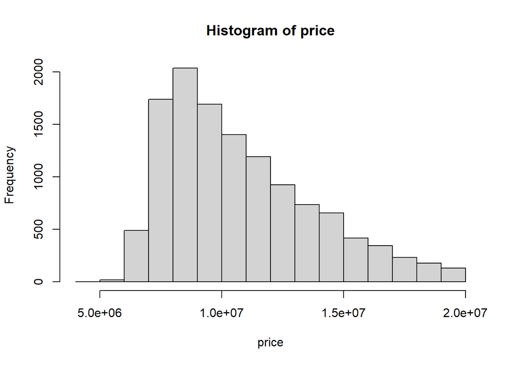

```r
hist(price)
```

Составляем из исходных данных нужную таблицу data1:

```r
threshold <- 800
data[, "sub_dist < threshold"] <- as.numeric(data$dist_to_subway < threshold)

data[, 'price_level'] <- as.numeric(data$price > 10 * 10^6) +
                          as.numeric(data$price > 15 * 10^6)
data$price_level <- as.factor(data$price_level)

data1 <- data[, c('price_level', 'sub_dist < threshold', 'AO')]
data1
```

| price_level | sub_dist < threshold | AO |
| --- | --- | --- |
| 0 | 0 | UAO |
| 0 | 0 | UAO |
| 1 | 1 | UAO |
| 0 | 0 | UAO |
| 0 | 1 | UAO |
| 0 | 0 | UAO |
| 1 | 1 | UAO |
| 0 | 0 | UAO |
| 0 | 0 | UAO |
| 0 | 1 | UAO |

[output cut: 9990 more lines]

Преобрзауем data1 к виду многомерного массива с матрицами сопряженности для каждого административного округа:

```r
matrix.names <- c(levels(as.factor(data1$AO)))
row.names <- 0:2
col.names <- 0:1
arr <- array(dim = c(3, 2, 9),
             dimnames = list(price_level = row.names,
                             sub_dist_less_1000 = col.names,
                             AO = matrix.names))


for (ao in unique(data1$AO)) {
  ao_data <- data1[data1$AO == ao, ]
  arr[,,ao] <- table(ao_data)
}

arr
```

```
## , , AO = CAO
##
##            sub_dist_less_1000
## price_level  0   1
##           0 14  20
##           1 94 362
##           2 23 140
##
## , , AO = SAO
##
##            sub_dist_less_1000
## price_level   0   1
##           0 332 284
##           1 262 371
##           2  32 141
##
## , , AO = SVAO
##
##            sub_dist_less_1000
## price_level   0   1
##           0 421 317
##           1 256 287
##           2  54  53
##
## , , AO = SZAO
##
##            sub_dist_less_1000
## price_level   0   1
##           0 190 135
##           1 212 131
##           2  73  19
##
## , , AO = UAO
##
##            sub_dist_less_1000
## price_level   0   1
##           0 479 341
##           1 312 250
##           2  89  25
##
```

[output cut: 16 more lines]

```
## , , AO = VAO
##
##            sub_dist_less_1000
## price_level   0   1
##           0 625 305
##           1 225 132
##           2  27  48
##
## , , AO = ZAO
##
##            sub_dist_less_1000
## price_level   0   1
##           0 282 264
##           1 344 401
##           2 143 160
```

Таким образом, с помощью критерия Кохрана-Мантеля-Хензеля будем проверять гипотезу об отсутствии взаимосвязи между фактором расстояния до метро и фактором цены.

Проведем тест Кохрана-Мантеля-Хензеля:

```r
mantelhaen.test(arr)
```

```
##
##  Cochran-Mantel-Haenszel test
##
## data:  arr
## Cochran-Mantel-Haenszel M^2 = 41.738, df = 2, p-value = 8.644e-10
```

p-value < 0.05, значит, нулевая гипотеза отвергается, т.е. взаимосвязь между расстоянием до ближайшего метро и ценой квартиры есть.